# 오픈 마켓 상품 키워드를 이용한 쇼핑 트렌드 분석

# 서론

## 주제 선정 배경

온라인 쇼핑몰 활성화로 인해 소비자들은 시간과 장소에 구애 받지 않고 인터넷을 통해 원하는 상품을 검색하거나 구매할 수 있다. 오픈마켓이나 스마트 스토어의 창업자는 상품의 상위노출이나 다양한 카테고리에서 검색이 되어야하고, 소비자가 원하는 상품을 적재적소에 배치하여 구매자의 관심을유도하는 것은 실질적으로 중요한 요소이다[1]. 또한, 소비자들은 브랜드 이미지와 광고 속 문구, 상품 설명, 상품의 이름 등에 의해서 상품에 대한 이미지를 형성하고, 이것이 구매행동으로 이어지게 된다. 상품명 자체는 직접적이면서 간접적으로 소비자들과 소통할 수 있는 방법 중 하나로 상품의 품질 뿐만 아니라 기업의 이미지나 마케팅에 대한 사회적 관심이 높아지면서 상품명에 대한 중요성이 상대적으로 높아지고 있다[2].

따라서 온라인 쇼핑몰에서 소비자들의 관심 트렌드를 분석하여 이를 상품 판매에 활용하고 있다. 기존의 초기 상품 트렌드 분석에서는 온라인 쇼핑 환경에서 수집된 클릭 스트림이나 세션 타임과 같은 로드를 분석하였다. 혹은 고객의 상품 구매 로그 데이터를 이용하여 시간에 따른 쇼핑 트렌드를 분석하는 경우가 많다. 하지만 수집한 사용자 로그만을 고려한 트렌드 분석은 서비스 내에서 적극적인 활동을 했던 사용자의 특성은 고려할 수 있으나 활동이 적은 잠재적 고객의 특성을 반영하지 못하는 문제점이 있다.

또한, 흔히 이용하는 온라인 쇼핑몰인 쿠팡, 티몬, 위메프 등을 소셜 커머스로, 지마켓이나 11번가 등을 오픈마켓으로 구분하였지만 최근 들어 이러한 경계는 점차 사라지고 있다. 스마트폰이 가장 강력한 쇼핑 채널로 떠오르면서 두 진영이 서로 장점을 흡수하기 시작하고 모바일 커머스 혹은 큐레이션 커머스라는 말이 더 현실을 반영하고 있기 때문이다[3]. 이런 오픈마켓과 소셜커머스의 성공요인을 보기 위해 사용자 댓글을 감성분석한 논문과 설문조사를 통한 실증분석이 이루어지지만 이 역시, 사용자의 관점에서 분석되어 판매자나 창업자의 관점이 반영되지 못하는 문제점이 있다. 따라서, 본 프로젝트에서는 관점을 판매자나 창업자의 입장으로 보고 텍스트 마이닝을 이용해 각 플랫폼에서의 차이와 직관적인 실시간 상품 트렌드를 파악하여 사업아이템을 선정하는 것을 제공하도록 하고자 한다.

본 프로젝트에서의 Research Question는 다음과 같다.

- Research Questions  
  Q. 도출되는 키워드를 통해 현 시점에서 가장 많이 팔리는 상품은 무엇인가?  
  Q. 베스트 상품들의 주요 키워드가 무엇인가? 상품이 주제별로 나누어지는가?  
  Q. 각 플랫폼 마다 베스트 상품에 사용되는 키워드는 무엇인가?

## 분석 Process

본 프로젝트의 분석 절차로 Python Selenium 라이브러리를 이용하여 대형 오픈 마켓 11번가, 위메프, 티몬 3가지 플랫폼의 베스트 상품의(각각 500개, 200개, 200개) 상품명을 크롤링 하였다. 위메프와 티몬의 경우 소셜커머스 기반의 플랫폼이었지만, 전자상거래의 발달과 기업의 혁신들로 인해 사실상 소셜커머스의 범주를 넘어섰기 때문에 오픈 마켓과 소셜커머스의 뚜렷한 차이점이 희미해져가고 있다. 따라서, 본 프로젝트에서는 플랫폼을 모두 오픈 마켓이라 가정하고 데이터 수집을 하였고, 플랫폼 중에서도 베스트 상품란이 따로 존재하는 위의 세개의 플랫폼을 선정하였다. 수집된 데이터를 Python의 한국어 형태소 분석기인 Okt를 사용하여 토큰화 및 불용어 제거 등의 전처리를 진행하였다. 다음으로 단어의 중요도 파악(베스트 상품들의 주요 키워드가 무엇인지)을 위해 TF-IDF 기법을 이용하였고, 확인을 위해 Bi-gram을 사용하였다. 또한 현시점에서 가장 많이 팔리는 전체적인 상품 파악을 위해 워드클라우드로 빈도가 높은 단어를 확인하였고 마지막으로 LDA를 통하여 각 플랫폼마다 상품의 주제가 어떻게 나뉘는지 파악하고자 하였다.

- **Process**  
  1) 데이터수집  
  2) 텍스트 전처리  
  3) TF-IDF & N-gram(Bi-gram)  
  4) Wordcloud  
  5) LDA

## 선행연구

트렌드 및 사용자 인식 분석에 대한 연구는 다양한 분야에서 이루어지고 있다. 특히 소셜 미디어나 커뮤니티의 게시물과 같은 비정형 문서에 대한 분석에 대한 방법으로 키워드 빈도 분석, LDA(Latent Dirichlet allocation) 토픽 모델링 등의 방법이 있다. 특히, 소셜 미디어와 같은 비정형 문서에 대한 언어 분석은 언어통계학적으로 중요하게 다루어지고 있다.

이동우, 김유신, 신은정(2021)은 뉴스, 블로그, 카페의 게시물을 수집하여 '액티브 시니어'를 키워드로 TF-IDF 및 LDA 분석을 통해 새로운 소비자층으로 떠오르는 액티브 시니어를 대상으로 그들의 특징과 액티브 시니어와 관련된 트렌드를 파악하고자 하였다[5]. 박수빈, 최도진, 유재수, 복경수(2019)는 소셜 네트워크 데이터를 이용하여 시간 속성을 고려한 TF-IDF 기법을 통해 핫 토픽 지수를 계산하고 온라인 쇼핑몰에서 상품 구매나 구매 후기 작성과 같은 상품을 추천하기 위해 수집된 데이터와 소셜 네트워크 데이터를 결합하여 상품의 트렌드를 분석하는 기법을 제안한다[1]. 또, 이진명, 나종연(2015)는 해외 직접 구매에 대한 소비자들의 경향을 알아보기 위해 온라인 커뮤니티의 글을 대상으로 키워드 빈도 분석을 진행하였고[6], 허준석, 이은정(2019)의 연구에서는 특정 브랜드의 트렌드를 분석하고자 다양한 채널을 통해 해당 브랜드와 관련된 문서들을 수집하고, TF, TF-IDF 값을 도출하여 트렌드를 분석하였다[7]. 한기향(2019)는 TF-IDF를 통해서 하이 서울 패션쇼에 대한 소비자 인식을 조사하는 연구를 진행하였다[8].

## 방법론

### TF-IDF 및 N-gram

- TF-IDF(Term Frequency-Innerse Document Frequency) : 단어의 빈도와 역문서 빈도를 사용하여 DTM 내의 각 단어들마다 중요한 정도를 가중치로 주는 방법으로 DTM을 만든 후, TF-IDF 가중치를 부여함

$$ TF×IDF $$$$ 단, IDF(d,t) = ln({n \over 1+df(t)}) $$

이 때,

TF(d,t) : Term Frequency의 줄인 말로 단어빈도 즉, 특정 문서 d에서의 특정 단어 t의 등장 횟수를 의미  
DF(t) : 특정 단어 t가 등장한 문서의 수(값이 클수록 흔한 단어라고 할 수 있음)  
IDF : DF의 역수를 취한 값을 의미, 즉 (전체 문서 수 / 해당 단어가 나타난 문서 수)로 한 단어가 문서 집합 전체에서 얼마나 공통적으로 나타나는지를 보여주며, 단어 자체가 문서군 내에서 자주 사용되는 경우, 그 단어가 흔하게 등장한다는 것을 의미(IDF는 값이 클수록 흔하지 않은 단어라고 할 수 있음)

- N-gram 언어모델(N-gram Language Model) : 통계와 확률을 바탕으로 한 색인 분석 등에 쓰이는 방식으로 검색시스템에서 키워드 추출이라든지, 악성코드의 API 추출 등 다방면에서 사용된다. 이 때, n개의 문자열 크기만큼 창(window)를 만들어 문자열을 왼쪽에서 오른쪽으로 한 단위씩 움직이며 추출되는 시컨스의 집합의 출현빈도수를 기록하는 것으로, n은 몇개의 단위로 잘라낼지를 나타내는 지표이다.

### LDA

- 토픽은 한국어로 주제라고 하고 토픽 모델링은 기계 및 자연어 처리 분야에서는 토픽이라는 문서집합의 추상적인 주제를 발견하기 위한 통계적 모델 중 하나로, 텍스트 본문의 숨겨진 의미 구조를 발견하기 이해 사용되는 텍스트 마이닝 기법이다.
- LDA는 이산 자료들에 대한 확률적 생성 모형이다. 문자 기반의 자료들에 대해 쓰일 수 있으며 사진 등의 다른 이산 자료들에 대해서도 쓰일 수 있다.[1] 기존의 정보 검색분야에서 LDA와 유사하게 문헌 내의 잠재적인 의미구조를 파악하려는 시도들은 계속 이루어져 왔다. TF-IDF를 필두로 하여 잠재 의미 분석(Latent semantic indexing, LSI), 확률 잠재 의미 분석(Probabilistic latent semantic analysis, pLSA)등을 거쳐 LDA로 도달하게 되었고, 이는 토픽 모델링이라 불리는 분야를 탄생시켰다. 확률 잠재 의미 분석은 확률 잠재 의미 인덱싱(probabilistic latent semantic indexing, pLSI) 라고도 한다.
- LDA에는 몇 가지 가정이 있는데 그 중 중요한 것은 단어의 교환성(exchangeability)이다. 이는 '단어 주머니(bag of words)'라고 표현하기도 한다. 교환성은 단어들의 순서는 상관하지 않고 오로지 단어들의 유무만이 중요하다는 가정이다. 예를 들어, 'Apple is red'와 'Red is apple' 간에 차이가 없다고 생각하는 것이다. 단어의 순서를 무시할 경우 문헌은 단순히 그 안에 포함되는 단어들의 빈도수만을 가지고 표현이 가능하게 된다. 이 가정을 기반으로 단어와 문서들의 교환성을 포함하는 혼합 모형을 제시한 것이 바로 LDA이다. 하지만 단순히 단어 하나를 단위로 생각하는 것이 아니라 특정 단어들의 묶음을 한 단위로 생각하는 방식(n-gram)으로 LDA의 교환성 가정을 확장시킬 수도 있다.
- LDA는 문헌의 주제를 찾기 위한 방법으로 고안되었지만, 이미지, 소리 등 텍스트 처리 이외의 다양한 분야에 쓰일 수 있고 이산 자료들, 즉 불연속적인 자료들뿐만 아니라 연속적인 자료들에 대해서 적용 할 수 있고 또한 다항 분포가 아닌 자료들에 대해서도 적용 할 수 있는 가능성이 있다.
- LDA에서 각각의 문서는 여러개의 주제를 가지고 있다. 확률 잠재 의미 분서과 비슷하지만 주제들이 디리클레 분포를 따른다고 가정한다. 예를 들어 [양자역학, 힉스 입자, 맥스웰 방정식, 상대성 이론, 불확정성 원리] 등의 단어들이 많이 쓰인 문서와 [셰익스피어, 톨스토이, 파우스트, 1984] 등의 단어가 많이 쓰인 문서가 있다고 할때, 첫번째 문서가 물리학에 관련된 내용이고, 두번째 문서가 문학에 관련된 내용으로 추측할 수 있다. 그 이유는 우리는 문서에 들어가 있는 단어들이 해당 주제들을 표현하고 있음을 알기 때문이다. 이러한 사전 정보가 없다면 주제를 예측할 수 없다. 하지만 사전 정보가 없어도 단어들과 주제들은 연관성이 있다. 주제는 의미나 인식으로 결정되는 것이 아니고, 지도학습으로 라벨링된 단어들의 가능도로 결정된다.

> TF-IDF 참고자료 [https://wikidocs.net/31698] , [https://wikidocs.net/21692]

> > 코드 [https://kavita-ganesan.com/tfidftransformer-tfidfvectorizer-usage-differences/#.Ybq9mGhByUk]

> LDA 참고자료 [https://wikidocs.net/30707], https://ko.wikipedia.org/wiki/%EC%9E%A0%EC%9E%AC_%EB%94%94%EB%A6%AC%ED%81%B4%EB%A0%88_%ED%95%A0%EB%8B%B9

> > 코드 [https://joyhong.tistory.com/138]  
> > 코드 [https://towardsdatascience.com/evaluate-topic-model-in-python-latent-dirichlet-allocation-lda-7d57484bb5d0]  
> > 코드 [https://happy-obok.tistory.com/5]

## 데이터 수집

```python
# 크롤링 시 필요한 모듈

import pandas as pd
from selenium import webdriver
from selenium.webdriver.common.keys import Keys
import time
import datetime
```

### 11번가 베스트 상품 크롤링

12월 9일 기준

```python
url = "https://www.11st.co.kr/browsing/BestSeller.tmall?method=getBestSellerMain&xfrom=main^gnb#pageNum%%13"
driver = webdriver.Chrome('C:/Users/BIS/Desktop/선민/study/chromedriver.exe')
driver.get(url)

data_list = []
item_titles = driver.find_elements_by_css_selector("div.best_prd_box > div.viewtype.catal_ty > ul.cfix > li > div.box_pd.ranking_pd > a > div.pname > p")
print(len(item_titles))

for items in item_titles:
    title = items.text
    data_list.append(title)

df = pd.DataFrame(data_list)
print(df)

df.to_excel('11번가.xlsx')
```

### 티몬

```python
url = "http://www.tmon.co.kr/best?bestType=best_100&gender=0&age=0&price=0"
driver = webdriver.Chrome('C:/Users/EUNSEO/Desktop/민/chromedriver_win32/chromedriver.exe')
driver.get(url)

data_list = []

def get_page_data():
    # 상품명 확인
    item_titles = driver.find_elements_by_css_selector('#_dealList > li > a > div > div.info > p.title_name')

    for item in item_titles:
        title = item.text
        data_list.append(title)

# scroll 코드 (https://hello-bryan.tistory.com/194) 참고
# 이 방법은 무한로딩 데이터를 다 가져올 수 없으므로 적당히 가져올 때 사용
# datetime을 이용해서 정해진 초 동안 1초에 한번씩 스크롤 다운
def doScrollDown(whileSeconds):
    start = datetime.datetime.now()
    end = start + datetime.timedelta(seconds=whileSeconds)
    while True:
        driver.execute_script('window.scrollTo(0, document.body.scrollHeight);')
        time.sleep(1)
        if datetime.datetime.now() > end:
            break

for page in range(1):
    try:
        # 스크롤을 통해 html을 모두 내려줌
        doScrollDown(60)

        # 해당 페이지 데이터 수집
        get_page_data()

    except:
        print('수집 에러')

print(str(page) + "page 수집 끝")
print('수집 종료')

df = pd.DataFrame(data_list)
df.head()
df.to_excel('티몬_crawling.xlsx')
```

### 위메프

```python
url = "https://front.wemakeprice.com/best"
driver = webdriver.Chrome('C:/Users/EUNSEO/Desktop/민/chromedriver_win32/chromedriver.exe')
driver.get(url)

data_list = []

def get_page_data():
    # 상품명 확인
    item_titles = driver.find_elements_by_css_selector('#_contents > div > div > div.box_listwrap > div > div > a > div > div.item_cont > div.option_txt > p')

    for item in item_titles:
        title = item.text
        data_list.append(title)

def doScrollDown(whileSeconds):
    start = datetime.datetime.now()
    end = start + datetime.timedelta(seconds=whileSeconds)
    while True:
        driver.execute_script('window.scrollTo(0, document.body.scrollHeight);')
        time.sleep(1)
        if datetime.datetime.now() > end:
            break

for page in range(1):
    try:
        doScrollDown(60)

        # 해당 페이지 데이터 수집
        get_page_data()

    except:
        print('수집 에러')

print(str(page) + "page 수집 끝")
print('수집 종료')

df = pd.DataFrame(data_list)
df.head()
df.to_excel('위메프_crawling.xlsx')
```

## 텍스트 분석

```python
import pandas as pd
import numpy as np
import matplotlib.pyplot as plt
%matplotlib inline
import matplotlib.font_manager as fm
import matplotlib
import matplotlib.pyplot as plt
plt.rcParams['font.family'] = 'NanumGothic'
import seaborn as sns
import warnings
warnings.filterwarnings('ignore')

from collections import Counter
from tensorflow.keras.preprocessing.text import Tokenizer
from tensorflow.keras.preprocessing.sequence import pad_sequences
import re

from sklearn.feature_extraction.text import CountVectorizer
from sklearn.feature_extraction.text import TfidfVectorizer
from sklearn.feature_extraction.text import TfidfTransformer
```

```python
import os
path = 'C:/Users/BIS/Desktop/선민/대학원/수업/빅데이터를 활용한 경제 및 금융문제 분석/개인프로젝트'
# path = 'C:/Users/EUNSEO/Desktop/민'
os.chdir(path)
```

```python
street_11 = pd.read_excel('11번가.xlsx')
street_11.head()
```

|  | Unnamed: 0 | 0 |
| --- | --- | --- |
| 0 | 0 | 30%할인 뽀로로코딩/쓰기패드/화장가방/노트북/워터파크 |
| 1 | 1 | [뚜레쥬르] 제품교환권 1만원권 |
| 2 | 2 | [4시간만 15%] 숨쉬기 편한 브레스 마스크 KF94 100매 외 마스크 모음/대... |
| 3 | 3 | 에어프라이어 치킨 떴닭 로스트 1kg+1kg/100%국내산 |
| 4 | 4 | [롯데리아] 클래식치즈 콤보(클래식치즈버거+콜라) |

```python
timon = pd.read_excel('티몬_crawling.xlsx')
timon.head()
```

|  | Unnamed: 0 | 0 |
| --- | --- | --- |
| 0 | 0 | [히트상품] 10%쿠폰 + 굽네 닭가슴살 990원부터 골라담기 훈제/소맛닭/만두/볶... |
| 1 | 1 | [단하루] 코코도르 크리스마스 디퓨저 / 동백꽃 / 솔방울 / 목화솜 / 리필액 /... |
| 2 | 2 | [히트상품] 밀리의서재 1년 무제한 구독권 |
| 3 | 3 | [광고천재씬드롬] 배스킨라빈스 연말파티 케이크 20%혜택 |
| 4 | 4 | [단하루] 1+1+1 순살치킨 / 1kg+1kg 에어프라이어치킨 등 6종 모음전 /... |

```python
wemake = pd.read_excel('위메프_crawling.xlsx')
wemake.head()
```

|  | Unnamed: 0 | 0 |
| --- | --- | --- |
| 0 | 0 | 투썸플레이스 연말 X-MAS 케이크 15% 할인 |
| 1 | 1 | 사은품폭탄! 얼어붙은 마음 따뜻하게 달래주는 3900원 도서 골라... |
| 2 | 2 | 30%쿠폰/착한구두 겨울 슈퍼세일 부츠/로퍼/펌프스/플랫/스니커즈... |
| 3 | 3 | 45%쿠폰/ 에뛰드 전품목50% BIG 브랜드데이 |
| 4 | 4 | [35%+40%] 단 하루! 겨울 신상할인+BEST 아이템 모음... |

### 데이터 구조확인 및 변경

```python
street_11.columns = ['index', 'title']
timon.columns = ['index', 'title']
wemake.columns = ['index', 'title']

# street_11.head() 확인용
```

```python
# 중복확인
print(street_11['title'].nunique())
print(timon['title'].nunique())
print(wemake['title'].nunique())

# 11번가에만 중복상품 1개 존재하므로 제거
street_11 = street_11.drop_duplicates(subset = ['title'], ignore_index = True)
print('총 상품수 :', len(street_11))
```

```
499
200
200
총 상품수 : 499
```

### 데이터 전처리(텍스트 전처리)

```python
# 정제화 코드

from konlpy.tag import Okt
with open("C:/Users/BIS/Desktop/선민/대학원/수업/빅데이터를 활용한 경제 및 금융문제 분석/개인프로젝트/stopwords-ko.txt", encoding='utf-8') as files: # 구글마운트 필요
    stopwords = files.readlines()
# with open("C:/Users/EUNSEO/Desktop/민/stopwords-ko.txt", encoding='utf-8') as files:
#     stopwords = files.readlines()

okt = Okt()

other_stopwords = ['kg','10','20','30'] # 단어 계속 추가

for stopword in other_stopwords:
    stopwords.append(stopword)

clean_sent_street = []
for title in street_11['title']:
    clean_street = re.sub('[-=+,#/\?:^$.@*\"※~&%ㆍ!』\\''‘·|\(\)\[\]\<\>`\'…\"\“’]', '', title)
    clean_street = re.sub('[^ A-Za-z0-9가-힣]','', title)
    clean_sent_street.append(clean_street)

word_street = []
for sentences in clean_sent_street:
    s = []
    # 정규화
    s = okt.normalize(sentences)
    # 토큰화
    s = okt.morphs(sentences, stem = True) # stem 옵션은 일정 수준 정규화(어간추출)를 수행해줌
    # 불용어 제거
    s = [word for word in s if not word in stopwords]
    # 한글자 단어 제거
    s = [a for a in s if len(a) > 1]
    word_street.append(s)
```

```python
clean_sent_street[:3]
# word_street[:3]
```

```
['30할인 뽀로로코딩쓰기패드화장가방노트북워터파크',
 '뚜레쥬르 제품교환권 1만원권',
 '4시간만 15 숨쉬기 편한 브레스 마스크 KF94 100매 외 마스크 모음대형소형식약']
```

```python
clean_sent_timon = []
for title in timon['title']:
    clean_timon = re.sub('[-=+,#/\?:^$.@*\"※~&%ㆍ!』\\''‘·|\(\)\[\]\<\>`\'…\"\“’]', '', title)
    clean_timon = re.sub('[^ A-Za-z0-9가-힣]','', title)
    clean_sent_timon.append(clean_timon)

word_timon = []
for sentences in clean_sent_timon:
    s = []
    # 정규화
    s = okt.normalize(sentences)
    # 토큰화
    s = okt.morphs(sentences, stem = True) # stem 옵션은 일정 수준 정규화(어간추출)를 수행해줌
    # 불용어 제거
    s = [word for word in s if not word in stopwords]
    # 한글자 단어 제거
    s = [a for a in s if len(a) > 1]
    word_timon.append(s)
```

```python
clean_sent_timon[:3]
# word_timon[:3]
```

```
['히트상품 10쿠폰  굽네 닭가슴살 990원부터 골라담기 훈제소맛닭만두볶음밥 67종 모음전',
 '단하루 코코도르 크리스마스 디퓨저  동백꽃  솔방울  목화솜  리필액  DIY 모음전',
 '히트상품 밀리의서재 1년 무제한 구독권']
```

```python
clean_sent_wemake = []
for title in wemake['title']:
    clean_wemake = re.sub('[-=+,#/\?:^$.@*\"※~&%ㆍ!』\\''‘·|\(\)\[\]\<\>`\'…\"\“’]', '', title)
    clean_wemake = re.sub('[^ A-Za-z0-9가-힣]','', title)
    clean_sent_wemake.append(clean_wemake)

word_wemake = []
for sentences in clean_sent_wemake:
    s = []
    # 정규화
    s = okt.normalize(sentences)
    # 토큰화
    s = okt.morphs(sentences, stem = True) # stem 옵션은 일정 수준 정규화(어간추출)를 수행해줌
    # 불용어 제거
    s = [word for word in s if not word in stopwords]
    # 한글자 단어 제거
    s = [a for a in s if len(a) > 1]
    word_wemake.append(s)
```

```python
clean_sent_wemake[:3]
# word_wemake[:3]
```

```
['투썸플레이스 연말 XMAS 케이크 15 할인',
 '사은품폭탄 얼어붙은 마음 따뜻하게 달래주는 3900원 도서 골라',
 '30쿠폰착한구두 겨울 슈퍼세일 부츠로퍼펌프스플랫스니커즈']
```

#### 11번가

#### [1] TF-IDF 계산 및 IDF 값 확인

```python
# TF-IDF
# input데이터로 리스트 형태 데이터 필요

tfidf = TfidfVectorizer(max_features = 100)
tfidf_matrix = tfidf.fit_transform(clean_sent_street)

print(tfidf_matrix.shape)
print(tfidf_matrix.toarray())
```

```
(499, 100)
[[0.         0.         0.         ... 0.         0.         0.        ]
 [0.         0.         0.         ... 0.         0.         0.        ]
 [0.         0.39515108 0.         ... 0.         0.         0.        ]
 ...
 [0.         0.         0.         ... 0.         0.         0.        ]
 [0.         0.         0.         ... 0.         0.         0.        ]
 [0.         0.         0.         ... 0.         0.         0.        ]]
```

```python
# 모듈 import
count_vectorizer = CountVectorizer(ngram_range = (1, 1))
tfidf_transformer = TfidfTransformer() # DTM에서 tfidf로 점수 계산 시에 필요한 모듈

dtm = count_vectorizer.fit_transform(clean_sent_street) # 각 단어의 빈도수를 기록(DTM 생성)
# IDF 값이 낮을수록 특정 문서에 대한 고유성이 떨어짐
tfidf_vector = tfidf_transformer.fit_transform(dtm) # 문서의 TF-IDF 점수 계산

# 직관적 이해를 위해 idf 값을 확인(문서 집합 전체에서 한 단어가 얼마나 등장하는지 확인)
df_tfidf = pd.DataFrame(tfidf_transformer.idf_, index=count_vectorizer.get_feature_names(),columns=["idf_weights"])
df_tfidf.sort_values(by=['idf_weights']).head(10)
```

|  | idf_weights |
| --- | --- |
| 모음전 | 4.036554 |
| 겨울 | 4.079114 |
| best | 4.270169 |
| 대형 | 4.270169 |
| kf94 | 4.324236 |
| 모음 | 4.324236 |
| 크리스마스 | 4.381395 |
| 마스크 | 4.442019 |
| 국산 | 4.649659 |
| 대용량 | 4.816713 |

```python
df_tfidf.sort_values(by=['idf_weights'], ascending = False).head(10)
```

|  | idf_weights |
| --- | --- |
| 003 | 6.521461 |
| 신원본사 | 6.521461 |
| 아모레파티헤라 | 6.521461 |
| 아모레파티프리메라 | 6.521461 |
| 아모레파티설화수헤라프리메라 | 6.521461 |
| 아모레파티설화수 | 6.521461 |
| 아모레파티 | 6.521461 |
| 아르떼 | 6.521461 |
| 아로마틱 | 6.521461 |
| 아라크네 | 6.521461 |

- **idf_weights 값이 작을수록 문서에 흔히 등장하는 단어로 '겨울', '모음', '마스크', '크리스마스' 등의 단어들이 많이 등장했음을 알 수 있다. 또, idf_weights이 높은 단어(비교적 흔하지 않은 단어)는 아모레퍼시픽의 브랜드와 그 상품으로 대부분을 이루고 있다.**

#### [2] N-gram(Bi-gram)으로 확인

```python
bi_vectorizer = CountVectorizer(ngram_range = (2, 2))
transformer = TfidfTransformer()
bi_tfidf_bf = bi_vectorizer.fit_transform(clean_sent_street)
bi_tfidf = transformer.fit_transform(bi_tfidf_bf)

df_bi_idf = pd.DataFrame(transformer.idf_, index=bi_vectorizer.get_feature_names(),columns=["idf_weights"])
df_bi_idf.sort_values(by=['idf_weights']).head(10)
```

|  | idf_weights |
| --- | --- |
| 기프티콘 투썸플레이스 | 5.135167 |
| up to | 5.422849 |
| 대형 소형 | 5.605170 |
| 프로체인지 블랙샴푸 | 5.605170 |
| 모다모다 프로체인지 | 5.605170 |
| all standard | 5.605170 |
| a4 복사용지a4용지 | 5.828314 |
| 블랙샴푸 300g | 5.828314 |
| 컬러마스크 대형 | 5.828314 |
| 비타민c 1000 | 5.828314 |

```python
df_bi_idf.sort_values(by=['idf_weights'], ascending = False).head(10)
```

|  | idf_weights |
| --- | --- |
| 05220v 어댑터 | 6.521461 |
| 애플정품 아이폰 | 6.521461 |
| 암막 커튼 | 6.521461 |
| 암막커튼 맞춤 | 6.521461 |
| 암웨이 글리스터 | 6.521461 |
| 앙천의 볼트태클 | 6.521461 |
| 애견간식 강아지껌 | 6.521461 |
| 애견패드 20g | 6.521461 |
| 애경산업 랩신 | 6.521461 |
| 애플케어플러스 선택 | 6.521461 |

- **bigram으로 확인 결과 '기프티콘 투썸플레이스'는 크리스마스 상품에 해당하고, '마스크', '대형, 소형'이 겹치는 것을 알 수 있다.**
- **다음으로 모다모다 프로체인지 블랙샴푸, 복사용지, 비타민 c에 해당하는 상품이 더 많이 나오는 것으로 나왔다.**

#### [1] TF-IDF 변형 및 IDF 값 확인

```python
tfidf = TfidfVectorizer(max_features = 100)
tfidf_matrix = tfidf.fit_transform(clean_sent_timon)

print(tfidf_matrix.shape)
print(tfidf_matrix.toarray())
```

```
(200, 100)
[[0.         0.         0.61875132 ... 0.         0.         0.3335592 ]
 [0.         0.         0.         ... 0.         0.         0.        ]
 [0.         0.         0.         ... 0.         0.         1.        ]
 ...
 [0.         0.         0.         ... 0.         0.         0.        ]
 [0.         0.         0.         ... 0.         0.         0.        ]
 [0.         0.         0.         ... 0.         0.         0.        ]]
```

```python
dtm = count_vectorizer.fit_transform(clean_sent_timon)
tfidf_vector = tfidf_transformer.fit_transform(dtm)

df_tfidf = pd.DataFrame(tfidf_transformer.idf_, index=count_vectorizer.get_feature_names(),columns=["idf_weights"])
df_tfidf.sort_values(by=['idf_weights']).head(10)
```

|  | idf_weights |
| --- | --- |
| 히트상품 | 2.432104 |
| 단하루 | 2.432104 |
| 모음전 | 3.167811 |
| 티몬겨울이야기 | 3.212262 |
| 모음 | 3.595255 |
| 겨울 | 3.738356 |
| 만원의행복 | 3.738356 |
| 무료배송 | 3.738356 |
| 선착순 | 3.905410 |
| 최대 | 3.905410 |

```python
df_tfidf.sort_values(by=['idf_weights'], ascending = False).head(10)
```

|  | idf_weights |
| --- | --- |
| 반짝2천원쿠폰 | 5.610158 |
| 아는 | 5.610158 |
| 신상출시 | 5.610158 |
| 신선한 | 5.610158 |
| 신신호텔 | 5.610158 |
| 신영와코루 | 5.610158 |
| 신제품 | 5.610158 |
| 신지모루 | 5.610158 |
| 실리콘 | 5.610158 |
| 실속벌크 | 5.610158 |

- **흔하게 등장하는 단어로 '히트상품', '단하루', '모음전', '티몬겨울이야기', '만원의행복' 등의 주로 이벤트성의 마케팅 단어들이 흔하게 등장했음을 알 수 있다. 비교적으로 흔하지 않게 등장하는 키워드로 '신영와코루(여성속옷류)', '신신호텔', '신지모루' 등의 여러 범주의 상품들이 존재함을 알 수 있다.**

#### [2] N-gram(bi-gram)으로 확인

```python
bi_vectorizer = CountVectorizer(ngram_range = (2, 2))
bi_tfidf_bf = bi_vectorizer.fit_transform(clean_sent_timon)
bi_tfidf = transformer.fit_transform(bi_tfidf_bf)

df_bi_idf = pd.DataFrame(transformer.idf_, index=bi_vectorizer.get_feature_names(),columns=["idf_weights"])
df_bi_idf.sort_values(by=['idf_weights']).head(10)
```

|  | idf_weights |
| --- | --- |
| all국산 kf94 | 4.511545 |
| 닌텐도 스위치 | 4.693867 |
| 사은품 증정 | 4.693867 |
| 스파클 생수 | 4.693867 |
| 생수 2l | 4.917011 |
| 타이벡 조생감귤 | 4.917011 |
| 11 할인 | 5.204693 |
| 최대 50 | 5.204693 |
| 단하루 쁘리엘르 | 5.204693 |
| 구매수량별 사은품 | 5.204693 |

```python
df_bi_idf.sort_values(by=['idf_weights'], ascending = False).head(10)
```

|  | idf_weights |
| --- | --- |
| 10 즉시할인 | 5.610158 |
| 우동 골라담기 | 5.610158 |
| 연말감사세일 겨울자켓패딩슬랙스원피스사은품까지 | 5.610158 |
| 연말 홈파티 | 5.610158 |
| 연말 득템 | 5.610158 |
| 역할놀이 주방놀이 | 5.610158 |
| 역대급 sale | 5.610158 |
| 여아옷 남아옷 | 5.610158 |
| 여성팬티11 잠옷가을파자마잠옷세트원피스 | 5.610158 |
| 여성 블라우스니트가디건스커트팬츠 | 5.610158 |

- **bigram으로 확인했을 때, tfidf로 확인 하는 것보다 직접적인 상품에 대한 키워드가 더 많이 도출이되었다. kf94 마스크와, 생수, 감귤 등의 다양한 상품 키워드가 많이 도출이 되었고, 11번가와 비교했을 때, 이벤트성 마케팅 키워드들이 많이 들어있음을 체감할 수 있다.**
- **비교적 흔하지 않은 키워드 중에서는 겨울 의류 및 아동, 유아관련 제품이 도출이 되었다.**

#### 위메프

```python
tfidf = TfidfVectorizer(max_features = 100)
tfidf_matrix = tfidf.fit_transform(clean_sent_wemake)

print(tfidf_matrix.shape)
print(tfidf_matrix.toarray())
```

```
(200, 100)
[[0.         0.         0.         ... 0.         0.56609877 0.        ]
 [0.         0.         0.         ... 0.         0.         0.        ]
 [0.         0.         0.         ... 0.         0.         0.        ]
 ...
 [0.         0.         0.         ... 0.         0.         0.        ]
 [0.         0.         0.         ... 0.         0.         0.        ]
 [0.         0.         0.         ... 0.         0.         0.        ]]
```

```python
dtm = count_vectorizer.fit_transform(clean_sent_wemake)
tfidf_vector = tfidf_transformer.fit_transform(dtm)

df_tfidf = pd.DataFrame(tfidf_transformer.idf_, index=count_vectorizer.get_feature_names(),columns=["idf_weights"])
df_tfidf.sort_values(by=['idf_weights']).head(10)
```

|  | idf_weights |
| --- | --- |
| best | 3.412933 |
| 겨울 | 3.530716 |
| 모음전 | 3.595255 |
| fw | 4.106080 |
| 신상 | 4.106080 |
| 모음 | 4.223863 |
| 겨울신상 | 4.357395 |
| 골라담기 | 4.357395 |
| kf94 | 4.357395 |
| 베스트 | 4.511545 |

```python
df_tfidf.sort_values(by=['idf_weights'], ascending = False).head(10)
```

|  | idf_weights |
| --- | --- |
| 100 | 5.610158 |
| 어린이마스크소형 | 5.610158 |
| 애경 | 5.610158 |
| 애터미 | 5.610158 |
| 애플워치 | 5.610158 |
| 액체세제 | 5.610158 |
| 앤디애플 | 5.610158 |
| 앵콜국산20만개판매기념미니매트1개증정온세상김장매트절임통할인 | 5.610158 |
| 앵클부츠패딩슬립온컴포 | 5.610158 |
| 양념에 | 5.610158 |

- **위메프에서도 흔하게 등장하는 단어로 겨울, 모음전, 신상, kf94 등의 단어가 도출이 되었고, 비교적 흔하지 않은 단어로 전자제품부터 의류, 식품 등 다양하게 상품 키워드가 도출 되었다.**

#### [2] Bi-gram으로 검증

```python
bi_vectorizer = CountVectorizer(ngram_range = (2, 2))
transformer = TfidfTransformer()
bi_tfidf_bf = bi_vectorizer.fit_transform(clean_sent_wemake)
bi_tfidf = transformer.fit_transform(bi_tfidf_bf)

df_bi_idf = pd.DataFrame(transformer.idf_, index=bi_vectorizer.get_feature_names(),columns=["idf_weights"])
df_bi_idf.sort_values(by=['idf_weights']).head(10)
```

|  | idf_weights |
| --- | --- |
| 크리스마스 트리 | 5.204693 |
| 겨울 신상 | 5.204693 |
| 사은품 증정 | 5.204693 |
| tv방송상품 best | 5.204693 |
| 2l 24펫 | 5.204693 |
| 생수 2l | 5.204693 |
| 홈쇼핑 tv방송상품 | 5.204693 |
| 엔비룩 연말총결산 | 5.610158 |
| 에이블샵 겨울코디best | 5.610158 |
| 에어프라이어 치킨 | 5.610158 |

```python
df_bi_idf.sort_values(by=['idf_weights'], ascending = False).head(10)
```

|  | idf_weights |
| --- | --- |
| 100 국산자재 | 5.610158 |
| 양념에 찍어 | 5.610158 |
| 어덜트 노령견 | 5.610158 |
| 어린이마스크소형 50매국내제조 | 5.610158 |
| 얼라이브 멀티비타민 | 5.610158 |
| 얼라이브즈 신상 | 5.610158 |
| 얼어붙은 마음 | 5.610158 |
| 얼큰한 알탕코다리낙지 | 5.610158 |
| 에뛰드 전품목50 | 5.610158 |
| 에스쁘아 브랜드세일 | 5.610158 |

- **bigram으로 확인 결과, 크리스마스와 겨울 상품, best의류 상품 등이 비슷하게 잘 묶여서 도출된 것을 확인하였고, 비교적 흔하지 않게 등장하는 단어도 마스크, 식료품 등 idf값과 비슷하게 잘 묶여서 나온 것을 확인할 수 있다.**

### 워드 클라우드

#### 11번가

```python
from wordcloud import WordCloud

w = []
for sentences in clean_sent_street:
    noun = okt.normalize(sentences)
    noun = okt.nouns(sentences)
    noun = [word for word in noun if not word in stopwords]
    noun = [a for a in noun if len(a) > 1]
    w.append(noun)

ww = sum(w, [])
countww = Counter(ww)
noun_listww = countww.most_common(300)
```

```python
def draw_wordcloud(noun_list):
    # pont_path에 자신의 font 경로 삽입
    wc = WordCloud(font_path='C:/Users/BIS/Documents/NanumFontSetup_TTF_ALL/NanumBarunGothic.ttf',
                   background_color="white", max_font_size=60)
    cloud = wc.generate_from_frequencies(dict(noun_list))

    plt.figure(figsize=(10, 8))
    plt.axis('off')
    plt.imshow(cloud)
    plt.show()
```

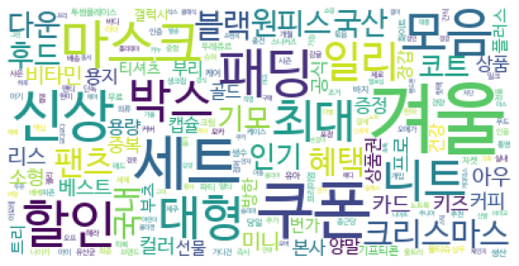

```python
draw_wordcloud(noun_listww)
```

#### 티몬

```python
from wordcloud import WordCloud

w = []
for sentences in clean_sent_timon:
    noun = okt.normalize(sentences)
    noun = okt.nouns(sentences)
    noun = [word for word in noun if not word in stopwords]
    noun = [a for a in noun if len(a) > 1]
    w.append(noun)

ww = sum(w, [])
countww = Counter(ww)
noun_listww = countww.most_common(300)
```

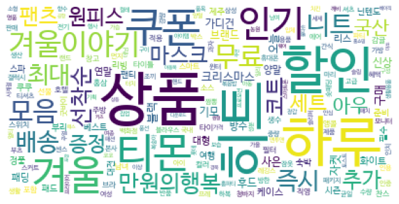

```python
draw_wordcloud(noun_listww)
```

- 티몬에서도 11번가와 마찬가지로 fw시즌을 맞아 '겨울', '겨울이야기'라는 키워드가 상품명에 포함이 많이 되어있음을 알 수 있고, 해당하는 의류 제품 및 선물 상품들이 판매 순위가 높음을 알 수 있다.
- 티몬에서는 상품명에 '무료 배송'과 '선착순', '히트 상품', '인기 상품'의 키워드가 많은 상품명의 앞쪽에 있음을 확인할 수 있고 '단하루', '만원의 행복' 등의 키워드로 티몬만의 다양한 상품들의 마케팅을 진행하고 있음을 알 수 있다.
- 또한, '스파', '제주'. '호텔', '숙박', '리스' 등의 키워드로 여행 상품을 찾는 사람이 많음을 알 수 있다.
- 마찬가지로 코로나의 여파로 티몬에서도 마스크의 구매율이 높다는 것을 알 수 있다.

#### 위메프

```python
from wordcloud import WordCloud

w = []
for sentences in clean_sent_wemake:
    noun = okt.normalize(sentences)
    noun = okt.nouns(sentences)
    noun = [word for word in noun if not word in stopwords]
    noun = [a for a in noun if len(a) > 1]
    w.append(noun)

ww = sum(w, [])
countww = Counter(ww)
noun_listww = countww.most_common(300)
```

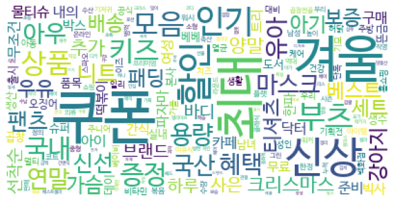

```python
draw_wordcloud(noun_listww)
```

- '겨울'시즌을 맞아서 다양한 의류로 니트나 패딩이 판매가 높고, 다른 플랫폼과는 다르게 겨울 신발(부츠)에 관한 상품이 좀 더 많음을 알 수 있다.
- 위메프는 '쿠폰', '할인', '신상', '증정', '인기', '최대~%'의 키워드로 마케팅을 하고 있음을 알 수 있다.
- 다른 플랫폼과는 조금 다르게 '아기 물티슈', '유아 물티슈' 등의 생필품과 '키즈'와 '강아지'관련 상품과 식료품 등의 상품 카테고리가 조금 더 많음을 알 수 있다.

#### 11번가

```python
import gensim
from gensim import corpora, models
from gensim.models import CoherenceModel

# 각 단어에 정수 인코딩을 실행
id2word = corpora.Dictionary(word_street) # 정수 인코딩과 빈도수 생성
id2word.filter_extremes(no_below=20) # 출현빈도가 작거나 자주 등장하는 단어는 제거
corpus = [id2word.doc2bow(text) for text in word_street]

# 단어에 정수 인코딩 재대로 되었는지 확인
# 두번째(index=1) 상품명의 단어가 어떻게 정수인코딩이 되고 그 등장횟수를 확인
print(corpus[1])
# 단어가 정수 인코딩 되기 전에 어떤 단어였는지 확인 -> dictionary를 통해 확인
print(id2word[1])
# 총 학습된 단어의 개수를 확인
print(len(id2word))
```

```
[]
100
19
```

```python
from gensim import corpora, models

tfidf = models.TfidfModel(corpus)
corpus_tfidf = tfidf[corpus]

from pprint import pprint

for doc in corpus_tfidf:
    pprint(doc)
    break
```

```
[(0, 1.0)]
```

```python
# 토픽별 coherence values 출력 함수
# coherence는 일관성 점수를 의미

def compute_coherence_values(dictionary, corpus, texts, limit, start=2, step=1):
    coherence_values = []
    model_list = []
    for num_topics in range(start, limit, step):
        model = gensim.models.LdaMulticore(corpus_tfidf, num_topics=num_topics, id2word = dictionary, passes=2, workers=4, random_state=1) # random_state를 사용시 고정
        model_list.append(model)
        coherencemodel = CoherenceModel(model=model, texts=texts, dictionary=dictionary, coherence='c_v') #c_v는 성능비교를 위한 메트릭
        coherence_values.append(coherencemodel.get_coherence())

    return model_list, coherence_values
```

```python
model_list, coherence_values = compute_coherence_values(dictionary=id2word, corpus=corpus, texts=word_street, limit=10, start=2, step=1)
```

```python
# 그래프로 시각화 하여 최적의 토픽수 찾는 함수 생성
# coherence_value가 가장 큰 값이 비교적 더 적합한 주제 갯수

def find_optimal_number_of_topics(dictionary, corpus, texts):
    limit = 10;
    start = 2;
    step = 1;

    model_list, coherence_values = compute_coherence_values(dictionary=dictionary, corpus=corpus, texts=texts, start=start, limit=limit, step=step)

    x = range(start, limit, step)
    plt.plot(x, coherence_values)
    plt.xlabel("Num Topics")
    plt.ylabel("Coherence score")
    plt.legend(("coherence_values"), loc='best')
    plt.show()
```

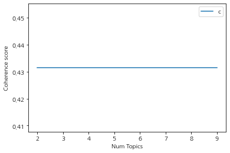

```python
find_optimal_number_of_topics(dictionary = id2word, corpus = corpus, texts = word_street)
```

```python
# 최적의 모델 할당
# compute_coherence_value에서 생성한 토픽중에서 리스트 0번이 가장 적합한 토픽 갯수가 있는 리스트

optimal_model = model_list[0]
model_topics = optimal_model.show_topics(formatted=False)
#pprint(optimal_model.print_topics(num_words=10))
model_topics
```

```
[(0,
  [('모으다', 0.088838704),
   ('ml', 0.08742005),
   ('할인', 0.086346105),
   ('세트', 0.084508546),
   ('11', 0.07196862),
   ('100', 0.06801981),
   ('대형', 0.06539483),
   ('마스크', 0.0582822),
   ('겨울', 0.05527081),
   ('50', 0.053621247)]),
 (1,
  [('겨울', 0.122725084),
   ('쿠폰', 0.09191617),
   ('모음', 0.087925255),
   ('박스', 0.078110114),
   ('신상', 0.07782556),
   ('세트', 0.0719977),
   ('BEST', 0.062328305),
   ('최대', 0.057629902),
   ('패딩', 0.05660419),
   ('니트', 0.04783904)])]
```

```python
# LDA 시각화

import pyLDAvis.gensim
import pickle
import pyLDAvis

pyLDAvis.enable_notebook()
vis = pyLDAvis.gensim.prepare(optimal_model, corpus_tfidf, id2word)
pyLDAvis.display(vis)
```

[interactive chart not shown]

#### 티몬

```python
id2word = corpora.Dictionary(word_timon)
id2word.filter_extremes(no_below=20)
corpus = [id2word.doc2bow(text) for text in word_timon]

print(corpus[1])
print(id2word[1])
print(len(id2word))
```

```
[(0, 1), (4, 1)]
상품
10
```

```python
from gensim import corpora, models

tfidf = models.TfidfModel(corpus)
corpus_tfidf = tfidf[corpus]

from pprint import pprint

for doc in corpus_tfidf:
    pprint(doc)
    break
```

```
[(0, 0.6167956088847922),
 (1, 0.3953445173341257),
 (2, 0.5410221708928736),
 (3, 0.4129901936809733)]
```

```python
model_list, coherence_values = compute_coherence_values(dictionary=id2word, corpus=corpus_tfidf, texts=word_timon, limit=10, start=2, step=1)
```

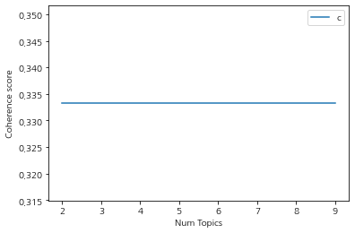

```python
find_optimal_number_of_topics(dictionary = id2word, corpus = corpus, texts = word_timon)
```

```python
optimal_model = model_list[0]
model_topics = optimal_model.show_topics(formatted=False)
model_topics
```

```
[(0,
  [('하루', 0.25911376),
   ('모으다', 0.12098939),
   ('쿠폰', 0.105742335),
   ('인기', 0.10281131),
   ('티몬', 0.09666113),
   ('겨울이야기', 0.0923166),
   ('상품', 0.06878809),
   ('겨울', 0.05662066),
   ('히트', 0.051662125),
   ('할인', 0.04529458)]),
 (1,
  [('할인', 0.1920009),
   ('히트', 0.17731972),
   ('상품', 0.17144684),
   ('하루', 0.09612301),
   ('쿠폰', 0.095163606),
   ('겨울', 0.09054317),
   ('티몬', 0.06354002),
   ('겨울이야기', 0.03995654),
   ('인기', 0.037368327),
   ('모으다', 0.036537945)])]
```

- 11번가와 마찬가지로 coherence score로 최적의 토픽수를 확인하였고, 토픽의 수를 조정해보았을 때, 모두 같은 정도의 score를 가지고 있기 때문에 최적의 토픽수를 2로 설정하였다. cherence score의 값이 대략 0.335 정도의 토픽들간의 일관성을 가진다고 할 수 있다.
- 도출된 첫번째 토픽으로 '하루, 모으다, 티몬, 인기, 쿠폰, 겨울 이야기, 겨울, 히트' 등의 키워드가 도출됨을 알 수 있는데, 해당 키워드들의 본 상품명을 확인해보았을 때, [단하루]특가, [티몬겨울이야기], [히트상품], [할인] 등의 키워드로 대부분의 상품 앞에 붙어있는 것을 알 수가 있다.
- 두번째 토픽도 마찬가지로 첫번째 토픽과는 별 다른 키워드 없이 비슷한 주제로 이루어져 있다.
- 해당 오픈마켓의 베스트 상품이 500개인 11번가와는 다르게 200개로 이루어져있어서, coherence score도 상대적으로 낮게 도출되었고 키워드 갯수가 작아서 티몬의 베스트 상품명으로는 어떤 상품들로 주제가 나뉘는지 확인하기가 쉽지가 않다는 한계점이 있다.
- 티몬의 대부분의 상품은 [단하루]라는 키워드가 대부분의 상품명에 들어 있음을 알 수 있다.

```python
pyLDAvis.enable_notebook()
vis = pyLDAvis.gensim.prepare(optimal_model, corpus_tfidf, id2word)
pyLDAvis.display(vis)
```

[interactive chart not shown]

#### 위메프

```python
id2word = corpora.Dictionary(word_wemake)
id2word.filter_extremes(no_below=20)
corpus = [id2word.doc2bow(text) for text in word_wemake]

print(corpus[1])
print(id2word[1])
print(len(id2word))
```

```
[]
쿠폰
5
```

```python
from gensim import corpora, models

tfidf = models.TfidfModel(corpus)
corpus_tfidf = tfidf[corpus]

from pprint import pprint

for doc in corpus_tfidf:
    pprint(doc)
    break
```

```
[]
```

```python
model_list, coherence_values = compute_coherence_values(dictionary=id2word, corpus=corpus_tfidf, texts=word_wemake, limit=10, start=2, step=1)
```

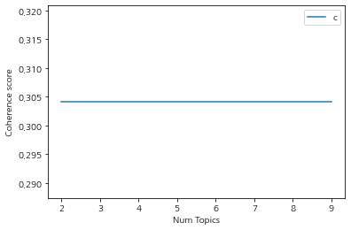

```python
find_optimal_number_of_topics(dictionary = id2word, corpus = corpus, texts = word_wemake)
```

```python
optimal_model = model_list[0]
model_topics = optimal_model.show_topics(formatted=False)
model_topics
```

```
[(0,
  [('최대', 0.33791924),
   ('겨울', 0.23288481),
   ('BEST', 0.21138863),
   ('쿠폰', 0.12867317),
   ('신상', 0.08913412)]),
 (1,
  [('쿠폰', 0.44830453),
   ('신상', 0.2318546),
   ('겨울', 0.15030028),
   ('최대', 0.085596174),
   ('BEST', 0.08394443)])]
```

- 나머지와 같은 방식으로 coherence socre를 기준으로 최적의 토픽의 수를 결정하였고, 모두 동일한 값이므로 최종적으로 2개로 지정하여 topic에 해당하는 키워드들 확인한 결과,
- 첫번째 토픽으로 '최대, 겨울, best, 쿠폰, 신상'으로 도출이 되었다. 마찬가지로 해당 키워드에 해당하는 상품명을 확인해본 결과 [최대~%까지 할인], [겨울특가], [쿠폰] 등의 키워드로 대부분의 상품 앞에 붙어있다는 것을 알 수 있다.
- 두번째 토픽 또한 첫번째 토픽과 차이가 별로 없다는 것을 알 수 있는데 티몬과 마찬가지로 베스트 상품이 200인 점에 대한 한계점이 존재하는 것으로 보인다.
- 티몬과 비교했을 때, 위메프의 대부분의 상품들은 [최대~%할인]이라는 수치적인 키워드가 많이 존재하고, 티몬의 상품들은 [단하루]라는 키워드가 많이 존재함을 알 수 있다.

```python
pyLDAvis.enable_notebook()
vis = pyLDAvis.gensim.prepare(optimal_model, corpus_tfidf, id2word)
pyLDAvis.display(vis)
```

[interactive chart not shown]

## Conclusion

11번가 베스트 상품은 코로나19로 인한 방역용품과 겨울시즌 관련 상품 두가지의 주제로 나뉜 것을 알 수 있다. 나머지 플랫폼에서는 주로 상품명에 붙는 할인 방법 및 이벤트와 같은 마케팅 관련 단어들로 이루어진 주제로 나뉜 것을 알 수 있는데, 이는 상품명이 11번가 비해 부족한 한계점으로 보인다.

IDF값과 워드 클라우드의 결과에서 보이듯 상품명에 붙는 마케팅 용어가 많이 등장하는데, 티몬은 일회성 이벤트와 높은 할인률을 볼 수 있고, 티몬과 비교했을 때, 위메프의 대부분의 상품들은 수치적인 할인 퍼센트를 제공하는 차이점이 있었다. 또한, 오픈마켓과 소셜커머스의 경계가 사라진 시점에도 여전히 상품마케팅에 있어서는 소셜커머스의 특성을 조금 엿볼 수 있는 부분이었다.

본 분석을 통해 각 플랫폼별 상품명의 특징 및 트렌드와 현 시점에서 가장 많이 팔리고 있는 제품들에 대해서 볼 수 있었다.

향후 좀 더 많은 상품명의 데이터 셋을 수집하여, 시간별 판매상품의 트렌드를 더 정확하게 분석하는 방향으로 발전시킬 수 있을 것이다. 또, LDA를 통해 주제를 세분하게 분류하고, 해당 상품명의 카테고리를 자동으로 분류하는 방향으로 발전시킬 수 있다. 이를 통해 오픈마켓의 창업자가 상품 판매시 소비자가 다양한 키워드로 검색하여도 정확한 카테고리에서 상품을 찾을 수 있게 하는 부분에도 도움을 줄 수 있다.

> [1] 온라인 쇼핑몰에서 소셜 네트워크 데이터를 고려한 상품 트렌드 분석, 2019  
> [2] 국내 화장품 브랜드의 상품명 분석, 2015  
> [3] ZDNet Korea(2017), 「"소셜커머스-오픈마켓 경계 사라진다」 https://zdnet.co.kr/view/?no=20170106182038  
> [4] 소셜커머스-오픈마켓 경계 https://m.blog.naver.com/PostView.naver?isHttpsRedirect=true&blogId=okss06&logNo=220906827687  
> [5] LDA 토픽 모델링을 이용한 액티브 시니어 콘텐츠 트렌드 분석, 2021  
> [6] Exploring Consumer Responses to the Cross-Border E-Commerce using Text-mining, 2015  
> [7] Trend Analysis of Fashion Brand Evaluation Using Big Data, 2019  
> [8] A study on the Consumer's Perception in Hi seoul Fashion show using big data analysis, 2019  
> [9] A study on the User Perception in Fashion Design through Social Media Text-mining, 2015  
> [10] Analysis of Socual Media Contents about Broadcast Media through Topic modeling, 2016  
> [11] A Study on Research Trends for Smart City using Topic Modeling, 2019  
> 참고문헌 Latent Dirichlet allocation(LDA) and topic modeling: models, applications, a survey, 2018